# Use of a calibration model for count data to predict cancer incidence in areas without cancer registry

Prediction of cancer incidence using cancer registry and hospitalization data

08 février, 2018

In this document, we illustrate the main features of the `CalibInc` R package through the example of estimating LOP cancer incidence in men for the 96 French metropolitan districts over the 2007-2011 period. The predictions are made using registry incidence data from 14 districts and hospitalization data for all the districts. This exemple served as an illustration of the method in the article *“For a sound use of healthcare data in epidemiology: evaluation of a calibration model for count data with application to prediction of cancer incidence in areas without cancer registry”*.

> **WARNING**

> *In order to comply with diffusion constrains,* *the numbers of cancer and hospitalizations in the datasets* *were slightly altered, while keeping the same value and district* *variability of the H/C ratio, as in the real data.*

# Installing CalibInc

Use devtools to install the latest version of `CalibInc` from Github (may take time):

```r
require(devtools)
install_github("echatignoux/CalibInc")
```

After installation, the package can be loaded into R.

```r
library(CalibInc)
```

# Using CalibInc

The use of `CalibInc` package is illustrated through the example of the prediction of LOP cancer incidence in men. The code can also be applied to the (altered) datasets for NHL cancer incidence in women (datasets `mhlw.CalibSet` and `mhlw.alldist`) which has significant variability in the H/C ratio.

*Note*: In addition to `CalibInc`, the following code needs the `Hmisc`, `lme4` and `gridExtra` packages to be installed.

## Cancer incidence and hospitalization data sets

The dataset `lopm.CalibSet` comprise data on LOP cancer in men over the 2007-2011 period for the 14 districts covered by a cancer registry. The number of cancer incident cases (variable `C`) and corresponding numbers of hospitalizations (variable `H`) for LOP cancer in men are tabulated by 5 years age groups (from 0-5 to 90+, variable `age` corresponds to the central age of each age group) and district (variable `dist`). In order to diminish the number of age groups with no cancer, the number of incident cases in lower ages groups were aggregated.

```r
library(tidyverse)
data(lopm.CalibSet)
lopm.CalibSet
```

```
## # A tibble: 182 x 5
##     dist      age     C     H       py
##    <chr>    <dbl> <dbl> <dbl>    <dbl>
##  1   d.1 23.05556     3     3 330156.5
##  2   d.1 32.50000     1     5  98607.0
##  3   d.1 37.50000     5     6 112337.5
##  4   d.1 42.50000    17    20 112521.0
##  5   d.1 47.50000    44    49 111290.0
##  6   d.1 52.50000    99   108 112793.0
##  7   d.1 57.50000   140   160 114357.0
##  8   d.1 62.50000   104   104 100545.5
##  9   d.1 67.50000    65    64  64945.5
## 10   d.1 72.50000    62    68  58179.5
## # ... with 172 more rows
```

The dataset `lopm.alldist` comprise hospitalization data for LOP cancer in men in all French district over the 2007-2011 period. The data are tabulated by 5 years age groups (from 0-5 to 90+, variable `age` corresponds to the central age of the age group) and district (variable `dist`). The variable `py` corresponds to the number of person years and `WSP` stands for the World Standard Population of 1960 (Segi standard).

```r
data(lopm.alldist)
lopm.alldist
```

```
## # A tibble: 1,728 x 5
##     dist   age     H       py   WSP
##    <chr> <dbl> <dbl>    <dbl> <dbl>
##  1    01   2.5     0  89984.5 12000
##  2    01   7.5     0 105461.0 10000
##  3    01  12.5     0 103710.0  9000
##  4    01  17.5     1  95027.0  9000
##  5    01  22.5     1  82120.0  8000
##  6    01  27.5     2  85621.0  8000
##  7    01  32.5     2  91905.0  6000
##  8    01  37.5     7 110688.0  6000
##  9    01  42.5    11 116016.0  6000
## 10    01  47.5    33 110742.0  6000
## # ... with 1,718 more rows
```

## Evaluation of the calibration model

### Estimation of model parameters

In the calibration model (2.1), the mean H/C ratio (exp(f)) is modelled with a restricted cubic spline with one knot at the median age (median over incident cases) and boundary knots placed at 5 years above and below the minimum and maximum age respectively (over all cases).

```r
library(splines)
library(Hmisc)## Used to calculate weighted quantiles
k<-wtd.quantile(lopm.CalibSet$age,weights=lopm.CalibSet$C,p=0.5)%>%as.numeric
form.calib<-substitute(H~offset(log(C))+
                         ns(age,knots=k, Boundary.knots = range(age)+c(5,-5))+
                         (1|dist),
                       list(k=k))
form.calib<-as.formula(form.calib)
```

The model can be evaluated with the `glmer`function from the `lme4` package:

```r
library(lme4)
mod.calib<-glmer(form.calib,data=lopm.CalibSet%>%filter(C>0),family="poisson", nAGQ =20)
summary(mod.calib)
```

```
## Generalized linear mixed model fit by maximum likelihood (Adaptive
##   Gauss-Hermite Quadrature, nAGQ = 20) [glmerMod]
##  Family: poisson  ( log )
## Formula:
## H ~ offset(log(C)) + ns(age, knots = 62.5, Boundary.knots = range(age) +
##     c(5, -5)) + (1 | dist)
##    Data: lopm.CalibSet %>% filter(C > 0)
##
##      AIC      BIC   logLik deviance df.resid
##    140.7    153.4    -66.4    132.7      170
##
## Scaled residuals:
##     Min      1Q  Median      3Q     Max
## -2.4189 -0.5233 -0.0554  0.6189  3.1889
##
## Random effects:
##  Groups Name        Variance Std.Dev.
##  dist   (Intercept) 0        0
## Number of obs: 174, groups:  dist, 14
##
## Fixed effects:
##                                                                 Estimate
## (Intercept)                                                     0.333754
## ns(age, knots = 62.5, Boundary.knots = range(age) + c(5, -5))1 -0.469144
## ns(age, knots = 62.5, Boundary.knots = range(age) + c(5, -5))2 -0.003146
##                                                                Std. Error
## (Intercept)                                                      0.067186
## ns(age, knots = 62.5, Boundary.knots = range(age) + c(5, -5))1   0.132741
## ns(age, knots = 62.5, Boundary.knots = range(age) + c(5, -5))2   0.037745
##                                                                z value
## (Intercept)                                                      4.968
## ns(age, knots = 62.5, Boundary.knots = range(age) + c(5, -5))1  -3.534
## ns(age, knots = 62.5, Boundary.knots = range(age) + c(5, -5))2  -0.083
##                                                                Pr(>|z|)
## (Intercept)                                                    6.78e-07
## ns(age, knots = 62.5, Boundary.knots = range(age) + c(5, -5))1 0.000409
## ns(age, knots = 62.5, Boundary.knots = range(age) + c(5, -5))2 0.933567
##
## (Intercept)                                                    ***
## ns(age, knots = 62.5, Boundary.knots = range(age) + c(5, -5))1 ***
## ns(age, knots = 62.5, Boundary.knots = range(age) + c(5, -5))2
## ---
## Signif. codes:  0 '***' 0.001 '**' 0.01 '*' 0.05 '.' 0.1 ' ' 1
##
## Correlation of Fixed Effects:
##                            (Intr) n(,k=62.5,B.=r()+c(5,-5))1
## n(,k=62.5,B.=r()+c(5,-5))1 -0.987
## n(,k=62.5,B.=r()+c(5,-5))2 -0.385  0.403
```

We can have a quick look at the mean H/C ratio:

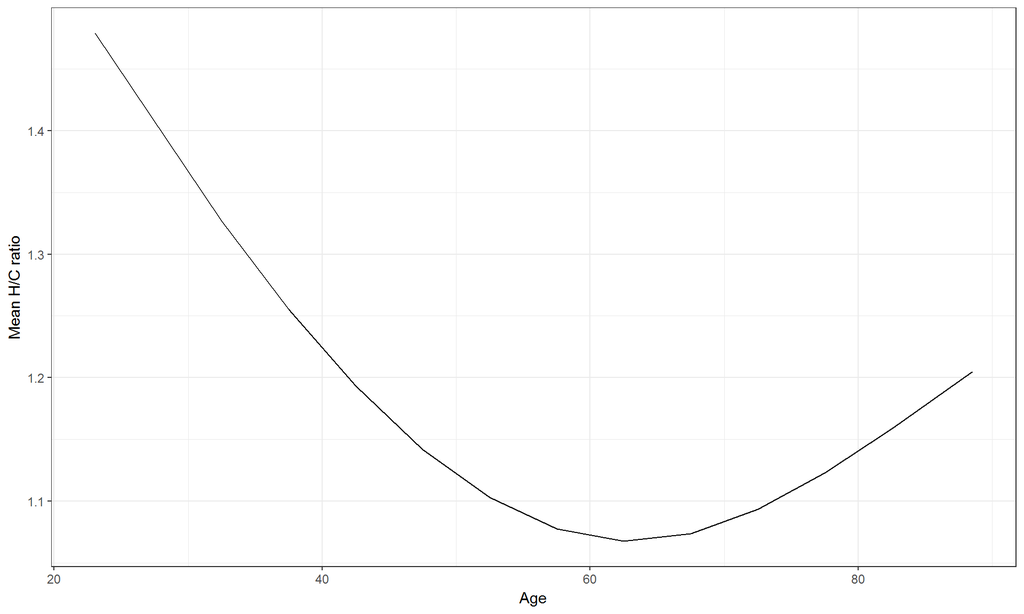

```r
age<-unique(lopm.CalibSet$age)
dtMeanHC<-data_frame(C=1,H=1,age=age)
## Predict H/C mean relation (i.e. predictions response with no random effects)
dtMeanHC$pred<-predict(mod.calib,newdata=dtMeanHC,re.form=NA,type="response")
## Display in a graph
qplot(data=dtMeanHC,age,pred,geom="line")+xlab("Age")+ylab("Mean H/C ratio")
```

The ratio has a U shape and is always greater that one (more hospitalisations than incident cases).

### Model diagnostics

Traditional diagnostic plots may be used to check the consistency between the model and the data. Note that residuals and fitted values includes eventual random effects.

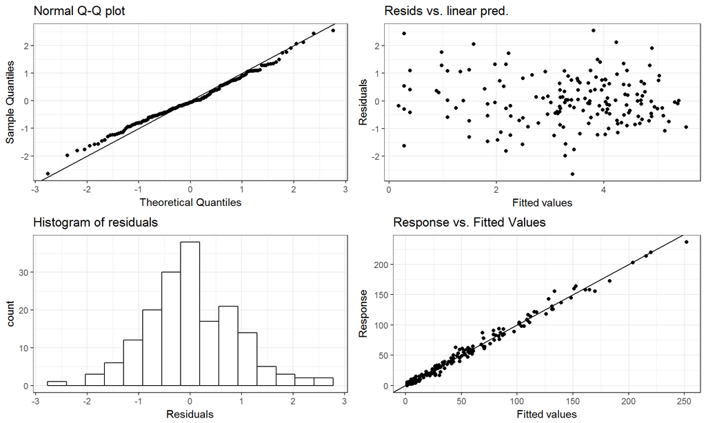

```r
## Build table with deviance residuals conditional on random effects and fitted values
diag.mod<-lopm.CalibSet%>%filter(C>0)
diag.mod<-mutate(diag.mod,
                 res=residuals(mod.calib,type="deviance"),
                 fit=predict(mod.calib,type="link"),
                 y=qqnorm(res,plot=F)$x)
## Bissectrice line
bis<-geom_abline(intercept=0,slope=1)

## Display traditionnal diagnotics plots in a 2x2 layout
library(gridExtra)
grid.arrange(
  qplot(data=diag.mod,y,res)+bis+xlab("Theoretical Quantiles")+ylab("Sample Quantiles")+bis+
    ggtitle("Normal Q-Q plot"),
  qplot(data=diag.mod,fit,res)+xlab("Fitted values")+ylab("Residuals")+
    ggtitle("Resids vs. linear pred."),
  qplot(data=diag.mod,res,fill=I("white"),colour=I("black"),bins=15)+xlab("Residuals")+
    ggtitle("Histogram of residuals"),
  qplot(data=diag.mod,exp(fit),H)+xlab("Fitted values")+ylab("Response")+bis+
    ggtitle("Response vs. Fitted Values"),
  ncol=2)
```

The residuals behave reasonably, although the QQ plot may suggest slight under-dispersion. This can be accounted for by estimating the GLMM model with a PQL routine (via the `glmmPQL` function from the `MASS` package):

```r
mod.calibPQL<-MASS::glmmPQL(nobars(form.calib),random=~1|dist,
                            data=lopm.CalibSet%>%filter(C>0),family="poisson")
mod.calibPQL$sigma
```

```
## [1] 0.887934
```

The PQL estimation confirms a small under-dispersion in the data.

# Prediction of incidence

Once the calibration model fit, predictions are done with the `CalibInc` function. This function takes the calibration model as an argument (`mod`) and requires a prediction table `pred` containing the proxy of incidence (hospitalisation data in this application) and the other variables used in the calibration model (only `age` and `dist` in this application). `CalibInc` has a `weight` argument used to weight row predictions, and an `aggregate` argument used to aggregate the predictions according to a combination of variables given as a formula (see below).

The output is a `data_frame` with predicted incidence `pred` and associated standard error `se`.

## Number of incident cases, crude and standardized rates

### 1. By age and district

Total number of incident cancer cases by age and district over the 2007-2011 period is predicted with:

```r
pred.dist.age.lopm<-CalibInc(mod.calib,pred=lopm.alldist,aggregate=~age+dist)
pred.dist.age.lopm
```

```
## # A tibble: 1,728 x 5
##      age  dist     H       pred       se
##    <dbl> <chr> <dbl>      <dbl>    <dbl>
##  1   2.5    01     0  0.0000000 0.000000
##  2   7.5    01     0  0.0000000 0.000000
##  3  12.5    01     0  0.0000000 0.000000
##  4  17.5    01     1  0.7725308 1.172716
##  5  22.5    01     1  0.8008820 1.202696
##  6  27.5    01     2  1.6569777 1.742605
##  7  32.5    01     2  1.7091830 1.781634
##  8  37.5    01     7  6.1485221 3.401189
##  9  42.5    01    11  9.8880394 4.336435
## 10  47.5    01    33 30.2061496 7.617809
## # ... with 1,718 more rows
```

Specific age-incidence rates by districts are obtained using the `weight` argument, with weights equal to the inverse of the number of person year by age in the district (times 100,000):

```r
cr.dist.age.lopm<-CalibInc(mod.calib,pred=lopm.alldist,aggregate=~age+dist,
                           w=100000/lopm.alldist$py)
cr.dist.age.lopm
```

```
## # A tibble: 1,728 x 5
##      age  dist         H       pred       se
##    <dbl> <chr>     <dbl>      <dbl>    <dbl>
##  1   2.5    01  0.000000  0.0000000 0.000000
##  2   7.5    01  0.000000  0.0000000 0.000000
##  3  12.5    01  0.000000  0.0000000 0.000000
##  4  17.5    01  1.052332  0.8129592 1.234087
##  5  22.5    01  1.217730  0.9752582 1.464559
##  6  27.5    01  2.335876  1.9352469 2.035254
##  7  32.5    01  2.176160  1.8597280 1.938561
##  8  37.5    01  6.324082  5.5548227 3.072771
##  9  42.5    01  9.481451  8.5229963 3.737790
## 10  47.5    01 29.798992 27.2761460 6.878880
## # ... with 1,718 more rows
```

### 2. By district

Total number of incident cancer cases by district over the 2007-2011 period is predicted with:

```r
pred.dist.lopm<-CalibInc(mod.calib,pred=lopm.alldist,aggregate=~dist)
pred.dist.lopm
```

```
## # A tibble: 96 x 4
##     dist     H      pred       se
##    <chr> <dbl>     <dbl>    <dbl>
##  1    01   463 424.04617 28.92116
##  2    02   554 508.61793 31.79272
##  3    03   451 413.97230 28.58864
##  4    04   160 145.67347 16.78007
##  5    05    96  87.70091 13.00025
##  6    06   846 771.39057 39.52444
##  7    07   322 294.66923 24.01317
##  8    08   316 289.72718 23.80785
##  9    09   152 139.36874 16.42959
## 10    10   281 257.98040 22.44895
## # ... with 86 more rows
```

Crude incidence rates by districts are obtained using the `weight` argument, with weights corresponding to the inverse of the number of person year in the district (times 100,000):

```r
lopm.alldist<-group_by(lopm.alldist,dist)
lopm.alldist<-mutate(lopm.alldist,w.cr=100000/sum(py))
cr.dist.lopm<-CalibInc(mod.calib,pred=lopm.alldist,aggregate=~dist,w=w.cr)
cr.dist.lopm
```

```
## # A tibble: 96 x 4
##     dist        H     pred       se
##    <chr>    <dbl>    <dbl>    <dbl>
##  1    01 31.58352 28.92628 1.972855
##  2    02 42.16469 38.71068 2.419730
##  3    03 54.85047 50.34717 3.476940
##  4    04 41.42792 37.71843 4.344772
##  5    05 28.86419 26.36892 3.908769
##  6    06 33.10113 30.18191 1.546458
##  7    07 42.07847 38.50692 3.138005
##  8    08 45.49017 41.70804 3.427289
##  9    09 41.20112 37.77729 4.453405
## 10    10 38.17222 35.04514 3.049559
## # ... with 86 more rows
```

Similarly, age standardized rate by district can be obtained by using a weight corresponding to the ratio between standard population figures and the number of person year by age and district:

```r
lopm.alldist$w.asr<-lopm.alldist$WSP/lopm.alldist$py
asr.dist.lopm<-CalibInc(mod.calib,pred=lopm.alldist,aggregate=~dist,w=w.asr)
asr.dist.lopm
```

```
## # A tibble: 96 x 4
##     dist        H     pred        se
##    <chr>    <dbl>    <dbl>     <dbl>
##  1    01 20.52797 18.83427 1.3185539
##  2    02 26.40929 24.29041 1.5631950
##  3    03 29.58490 27.26092 1.9878941
##  4    04 21.74951 19.86846 2.4567851
##  5    05 15.76216 14.46559 2.2581611
##  6    06 18.35559 16.82705 0.9241362
##  7    07 23.01547 21.10752 1.8107310
##  8    08 28.30508 25.91565 2.2025255
##  9    09 22.60764 20.78131 2.5921613
## 10    10 23.02931 21.19679 1.9090426
## # ... with 86 more rows
```

### 3. For the whole territory

The total number of incident for cases over 2007-2011 for France as a whole is predicted with:

```r
pred.fr.lopm<-CalibInc(mod.calib,pred=lopm.alldist,aggregate=~1)
pred.fr.lopm
```

```
## # A tibble: 1 x 3
##       H     pred       se
##   <dbl>    <dbl>    <dbl>
## 1 54820 50206.26 654.6587
```

and crude incidence rates obtained using the `weight` argument, with individual weights corresponding to the inverse of the total number of person year (times 100,000):

```r
lopm.alldist$w.cr.fr<-100000*1/sum(lopm.alldist$py)
cr.fr.lopm<-CalibInc(mod.calib,pred=lopm.alldist,aggregate=~1,w=w.cr.fr)
cr.fr.lopm
```

```
## # A tibble: 1 x 3
##          H    pred        se
##      <dbl>   <dbl>     <dbl>
## 1 36.16283 33.1193 0.4318553
```

Finally, age standardized rate for France are obtained by using a weight corresponding to the ratio between standardized population and the number of person year by age:

```r
lopm.alldist<-group_by(lopm.alldist,age)
lopm.alldist<-mutate(lopm.alldist,w.asr.fr=WSP/sum(py))
asr.fr.lopm<-CalibInc(mod.calib,pred=lopm.alldist,aggregate=~1,w=w.asr.fr)
asr.fr.lopm
```

```
## # A tibble: 1 x 3
##          H     pred        se
##      <dbl>    <dbl>     <dbl>
## 1 22.81673 20.93921 0.2710799
```

## Prediction of SIR

The following code provides example of how to use `CalibInc` to calculate SIR in each French districts.

### 1. Calculate expected incidence by district

The expected number of cases in a district is calculated as the sum of age-incidence rate for France times the total district’s person years.

```r
## Calculate french age-incidence rate with weight equal to
## the inverse of total number of person-years for the age group
lopm.alldist<-group_by(lopm.alldist,age)
lopm.alldist<-mutate(lopm.alldist,w.cr.fr.age=1/sum(py))
cr.fr.age.lopm<-CalibInc(mod.calib,pred=lopm.alldist,aggregate=~age,w=w.cr.fr.age)
## Add the rate to individual table
cr.fr.age.lopm<-select(cr.fr.age.lopm,age,pred)
cr.fr.age.lopm<-rename(cr.fr.age.lopm,ar=pred)
lopm.alldist<-left_join(lopm.alldist,cr.fr.age.lopm,by="age")
## Sum by district
SIR<-group_by(lopm.alldist,dist)
SIR<-summarise(SIR,E=sum(py*ar))
SIR
```

```
## # A tibble: 96 x 2
##     dist        E
##    <chr>    <dbl>
##  1    01 469.3374
##  2    02 441.0471
##  3    03 325.9110
##  4    04 150.3724
##  5    05 125.0040
##  6    06 925.3855
##  7    07 288.8643
##  8    08 237.0084
##  9    09 145.8537
## 10    10 254.7313
## # ... with 86 more rows
```

### 2. Add predicted number of incident cases by districts and standard errors

```r
SIR<-left_join(SIR,pred.dist.lopm)
SIR
```

```
## # A tibble: 96 x 5
##     dist        E     H      pred       se
##    <chr>    <dbl> <dbl>     <dbl>    <dbl>
##  1    01 469.3374   463 424.04617 28.92116
##  2    02 441.0471   554 508.61793 31.79272
##  3    03 325.9110   451 413.97230 28.58864
##  4    04 150.3724   160 145.67347 16.78007
##  5    05 125.0040    96  87.70091 13.00025
##  6    06 925.3855   846 771.39057 39.52444
##  7    07 288.8643   322 294.66923 24.01317
##  8    08 237.0084   316 289.72718 23.80785
##  9    09 145.8537   152 139.36874 16.42959
## 10    10 254.7313   281 257.98040 22.44895
## # ... with 86 more rows
```

### 3. Calculate the SIR and add prediction intervals thanks to `LogNormPI` function

```r
SIR<-mutate(SIR,SIR=pred/E,se.SIR=se/E)
SIR<-LogNormPI(SIR,pred=SIR,se=se.SIR)
SIR
```

```
## # A tibble: 96 x 9
##     dist        E     H      pred       se       SIR     se.SIR       low
##    <chr>    <dbl> <dbl>     <dbl>    <dbl>     <dbl>      <dbl>     <dbl>
##  1    01 469.3374   463 424.04617 28.92116 0.9034996 0.06162126 0.7924077
##  2    02 441.0471   554 508.61793 31.79272 1.1532055 0.07208464 1.0223472
##  3    03 325.9110   451 413.97230 28.58864 1.2702006 0.08771917 1.1122233
##  4    04 150.3724   160 145.67347 16.78007 0.9687512 0.11159010 0.7786600
##  5    05 125.0040    96  87.70091 13.00025 0.7015846 0.10399865 0.5312609
##  6    06 925.3855   846 771.39057 39.52444 0.8335883 0.04271132 0.7549805
##  7    07 288.8643   322 294.66923 24.01317 1.0200957 0.08312960 0.8726234
##  8    08 237.0084   316 289.72718 23.80785 1.2224344 0.10045153 1.0443799
##  9    09 145.8537   152 139.36874 16.42959 0.9555381 0.11264434 0.7642693
## 10    10 254.7313   281 257.98040 22.44895 1.0127548 0.08812794 0.8574566
## # ... with 86 more rows, and 1 more variables: up <dbl>
```

### 4. Represent the predicted SIR on a map

The `ggMap` function can be use to represent the predicted SIR on a map:

[figure not shown]

```r
SIR<-mutate(SIR,id=dist,NS=!(low>1|up<1))
ggMap(data=SIR,
      SIR,color= "RdYlGn",rev=T,ns=NS,limits=c(0.7,1.3))+
  ggtitle("SIR for LOP cancer incidence in men, 2007-2011")
```

## Comparison with PQL estimates

As we saw, slight under-dispersion is present in the data. We can account for the under-dispersion when calculating the variances of the prediction by using the `glmmPQL` fit in the `mod` argument of `CalibInc`.

```r
## Calculate french age-incidence rate
cr.fr.age.lopm.PQL<-CalibInc(mod.calibPQL,pred=lopm.alldist,aggregate=~age,w=w.cr.fr.age)
cr.fr.age.lopm.PQL<-select(cr.fr.age.lopm.PQL,age,pred)
cr.fr.age.lopm.PQL<-rename(cr.fr.age.lopm.PQL,ar.PQL=pred)
## Add the rate to individual table
lopm.alldist<-left_join(lopm.alldist,cr.fr.age.lopm.PQL,by="age")
## Sum by district to get expected counts
SIR.PQL<-group_by(lopm.alldist,dist)
SIR.PQL<-summarise(SIR.PQL,E=sum(py*ar.PQL))
## Add predicted number of incident cases by districts and standard errors
pred.dist.lopm.PQL<-CalibInc(mod.calibPQL,pred=lopm.alldist,aggregate=~dist)
SIR.PQL<-left_join(SIR.PQL,pred.dist.lopm.PQL)
## Calculte SIR and prediction intervals
SIR.PQL<-mutate(SIR.PQL,SIR=pred/E,se.SIR=se/E)
SIR.PQL<-LogNormPI(SIR.PQL,pred=SIR,se=se.SIR)
SIR.PQL
```

```
## # A tibble: 96 x 9
##     dist        E     H      pred       se       SIR     se.SIR       low
##    <chr>    <dbl> <dbl>     <dbl>    <dbl>     <dbl>      <dbl>     <dbl>
##  1    01 469.3943   463 424.09721 26.10642 0.9034988 0.05561726 0.8024176
##  2    02 441.1005   554 508.68018 28.78648 1.1532069 0.06526058 1.0338799
##  3    03 325.9495   451 414.02292 25.79611 1.2702057 0.07914143 1.1265015
##  4    04 150.3903   160 145.69005 14.98763 0.9687461 0.09965820 0.7964533
##  5    05 125.0190    96  87.71118 11.58512 0.7015830 0.09266688 0.5468794
##  6    06 925.4943   846 771.47905 36.11747 0.8335860 0.03902506 0.7613737
##  7    07 288.8987   322 294.70425 21.57127 1.0200953 0.07466724 0.8862973
##  8    08 237.0371   316 289.76243 21.38293 1.2224351 0.09020924 1.0609043
##  9    09 145.8709   152 139.38564 14.67096 0.9555410 0.10057496 0.7821601
## 10    10 254.7620   281 258.01202 20.13803 1.0127572 0.07904645 0.8719430
## # ... with 86 more rows, and 1 more variables: up <dbl>
```

The resulting predictions and standard errors are very close to the one obtained with the `glmer` function, as can be seen in the caterpillar graph below. In this graph, the districts are ordered by increasing SIR values and bars represent 95% PI.

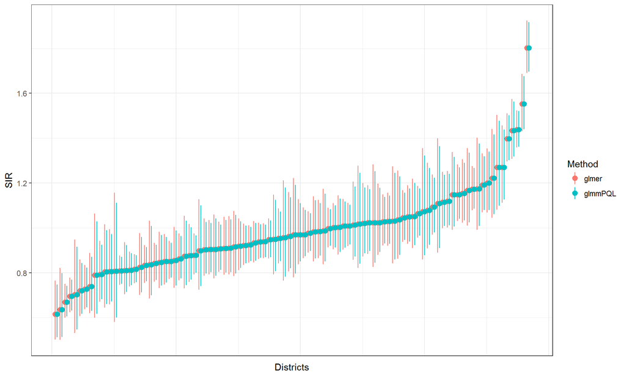

```r
## Regroup glmer and glmmPQL predicted incidence
SIR.compare<-bind_rows(
  mutate(SIR,Method="glmer"),
  mutate(SIR.PQL,Method="glmmPQL"))
## Arrange districts by increasing SIR
SIR<-arrange(SIR,SIR)
SIR$rank<-1:nrow(SIR)
SIR.compare<-left_join(SIR.compare,select(SIR,dist,rank))
SIR.compare<-mutate(SIR.compare,rank=rank-0.4*(Method=="glmer"))
## Plot
qplot(data=SIR.compare,rank,SIR,colour=Method)+geom_pointrange(aes(ymin=low,ymax=up))+
  xlab("Districts")+theme(axis.text.x=element_blank(),axis.ticks.x=element_blank())
```

Only small differences were expected here as dispersion was low. However, in case of marked dispersion, the use of `glmmPQL` is recommended.